# Proyecto de Estadística

## Regresion y ACP

Primero vamos a importar las bibliotecas necesarias, leer la base de datos, filtrarla por los equipos de la fase de grupos de la UEFA Champions League, cambiarle el nombre a las variables para reducirle el tamaño (para que sea más comodo trabajar con ellas) y por último veremos una descripción general de los datos utilizando la función `skim` de la biblioteca `skimr`.

```r
library(corrplot)
library(skimr)
library(lmtest)
library(rpart)
library(nortest)

db <- read.csv(file = 'database.csv')

uefa_teams = c(
    'AtlÃ©tico Madrid',
    'Juventus',
    'Olympiacos CFP',
    'MalmÃ¶ FF',
    'Real Madrid',
    'FC Basel 1893',
    'Liverpool',
    'AS Monaco',
    'Bayer 04 Leverkusen',
    'Zenit St. Petersburg',
    'SL Benfica',
    'Borussia Dortmund',
    'Arsenal',
    'RSC Anderlecht',
    'Galatasaray SK',
    'FC Bayern MÃ¼nchen',
    'Manchester City',
    'Roma',
    'PFC CSKA Moscow',
    'FC Barcelona',
    'Paris Saint-Germain',
    'Ajax',
    'Chelsea',
    'FC Schalke 04',
    'Sporting CP',
    'FC Porto',
    'Shakhtar Donetsk',
    'Athletic Club de Bilbao'
)

uefa_db <- data.frame(db[db$club %in% uefa_teams, ])

short_db <- data.frame(
    uefa_db$overall,
    uefa_db$potential,
    uefa_db$attacking_finishing,
    uefa_db$attacking_short_passing,
    uefa_db$skill_ball_control,
    uefa_db$skill_fk_accuracy,
    uefa_db$skill_long_passing,
    uefa_db$movement_agility,
    uefa_db$movement_balance,
    uefa_db$movement_sprint_speed,
    uefa_db$power_shot_power,
    uefa_db$power_stamina,
    uefa_db$power_long_shots,
    uefa_db$mentality_interceptions,
    uefa_db$mentality_vision,
    uefa_db$defending_marking,
    uefa_db$defending_sliding_tackle
)

colnames(short_db) <- c(
    "overall",
    "potential",
    "attacking_finishing",
    "attacking_short_passing",
    "skill_ball_control",
    "skill_fk_accuracy",
    "skill_long_passing",
    "movement_agility",
    "movement_balance",
    "movement_sprint_speed",
    "power_shot_power",
    "power_stamina",
    "power_long_shots",
    "mentality_interceptions",
    "mentality_vision",
    "defending_marking",
    "defending_sliding_tackle"
)

data_sum <- skim(short_db)
data_sum
```

```
-- Data Summary ------------------------
                           Values
Name                       short_db
Number of rows             828
Number of columns          17
_______________________
Column type frequency:
  numeric                  17
________________________
Group variables            None

-- Variable type: numeric -----------------------------------------------------------------
# A tibble: 17 x 11
   skim_variable            n_missing complete_rate  mean    sd    p0   p25   p50   p75
 * <chr>                        <int>         <dbl> <dbl> <dbl> <dbl> <dbl> <dbl> <dbl>
 1 overall                          0             1  72.9  8.31    49    68  74      79
 2 potential                        0             1  78.1  6.10    58    74  79      83
 3 attacking_finishing              0             1  52.9 19.3     20    36  56      68
 4 attacking_short_passing          0             1  65.8 16.5     20    60  70      77
 5 skill_ball_control               0             1  66.5 17.7     20    61  72      78
 6 skill_fk_accuracy                0             1  51.5 18.2     20    36  51      67
 7 skill_long_passing               0             1  60.4 16.6     21    52  64      72
 8 movement_agility                 0             1  67.8 14.8     25    59  70      78
 9 movement_balance                 0             1  65.5 14.4     27    57  66      76
10 movement_sprint_speed            0             1  70.2 13.5     29    64  72.5    79
11 power_shot_power                 0             1  64.2 17.2     20    55  69      77
12 power_stamina                    0             1  67.3 16.3     21    61  71      78
13 power_long_shots                 0             1  56.4 19.0     20    41  60.5    72
14 mentality_interceptions          0             1  53.5 22.4     20    29  57      74
15 mentality_vision                 0             1  58.9 18.2     20    47  62      73
16 defending_marking                0             1  49.6 22.0     20    25  50.5    71
17 defending_sliding_tackle         0             1  51.6 22.3     20    25  56      73
    p100 hist
 * <dbl> <chr>
 1    93 ▁▃▆▇▁
 2    95 ▁▂▇▆▁
 3    95 ▇▆▇▇▂
 4    95 ▂▁▃▇▂
 5    96 ▂▁▃▇▃
 6    93 ▇▇▆▇▂
 7    95 ▂▂▆▇▁
 8    94 ▁▂▅▇▃
 9    97 ▂▃▇▇▂
10    96 ▁▂▆▇▃
11    94 ▂▂▃▇▃
12    95 ▂▁▃▇▃
13    93 ▅▃▅▇▂
14    93 ▇▃▃▇▅
15    96 ▃▃▆▇▂
16    90 ▇▂▃▆▂
17    95 ▇▂▃▆▂
```

### Analisis de correlacion de las variables seleccionadas

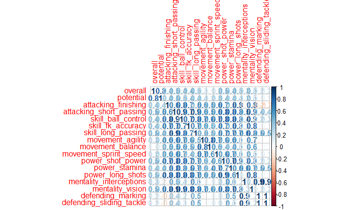

```r
cor_short_db <- cor(short_db)
corrplot(cor_short_db, method = "number", number.digits=1)
```

Se puede observar una alta correlación entre las variables, por lo que no sería correcto aplicar una regresión lineal, por lo tanto aplicaremos una reducción de dimensiones para obtener nuevas variables que sean independientes entre si y que sean dependientes de una variable respuesta que elijamos.

### Reducción de dimensiones

Seleccionaremos la variable `overall` como variable respuesta. Por lo que la sacaremos de las variables que vayamos a aplicarle el ACP.

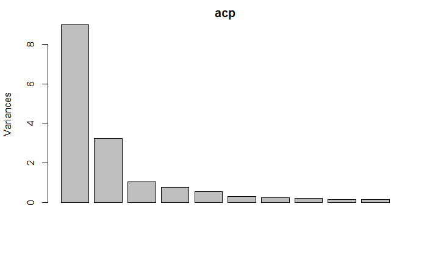

```r
idx_var_answer <- 1
acp <- prcomp(short_db[-c(idx_var_answer)], scale. = TRUE)
plot(acp)
```

```r
summary(acp)
```

```
Importance of components:
                          PC1    PC2     PC3     PC4     PC5     PC6     PC7     PC8
Standard deviation     2.9998 1.8015 1.02576 0.87163 0.74757 0.53447 0.47729 0.44698
Proportion of Variance 0.5624 0.2028 0.06576 0.04748 0.03493 0.01785 0.01424 0.01249
Cumulative Proportion  0.5624 0.7653 0.83102 0.87850 0.91343 0.93129 0.94552 0.95801
                           PC9    PC10    PC11    PC12    PC13    PC14    PC15   PC16
Standard deviation     0.38960 0.37894 0.31884 0.29301 0.25416 0.24031 0.19436 0.1697
Proportion of Variance 0.00949 0.00897 0.00635 0.00537 0.00404 0.00361 0.00236 0.0018
Cumulative Proportion  0.96750 0.97647 0.98283 0.98819 0.99223 0.99584 0.99820 1.0000
```

Aplicando el criterio de Kaiser, podemos quedarnos con las primeras tres variables. Pasaremos a crear una matriz con la variable respuesta junta las tres variables nuevas seleccionadas generadas por el ACP y analizar sus correlaciones.

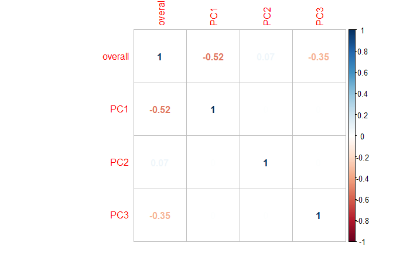

```r
reg_data <-
  as.data.frame(cbind(scale(short_db[c(idx_var_answer)]), acp$x[, 1:3]))
cor_reg_data <- cor(reg_data)
corrplot(cor_reg_data, method = "number")
```

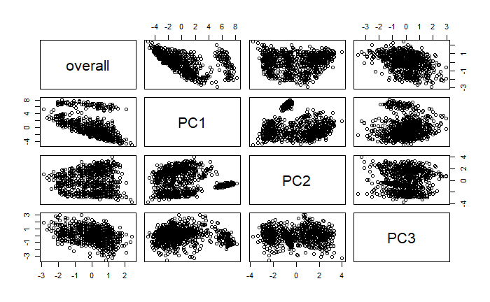

```r
pairs(reg_data)
```

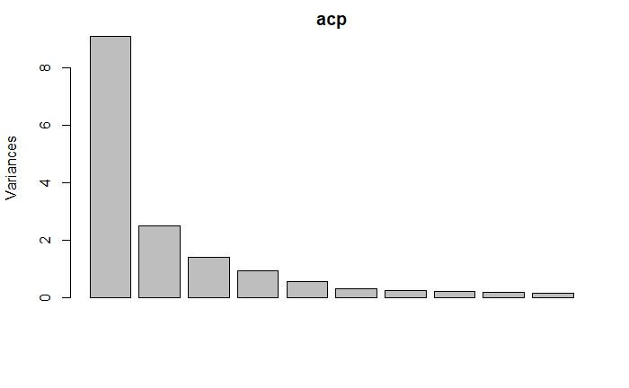

```r
idx_var_answer <- 14
acp <- prcomp(short_db[-c(idx_var_answer)], scale. = TRUE)
plot(acp)
```

```r
summary(acp)
```

```
Importance of components:
                          PC1    PC2     PC3     PC4     PC5     PC6     PC7     PC8
Standard deviation     3.0188 1.5818 1.17661 0.96349 0.74847 0.54738 0.47747 0.46159
Proportion of Variance 0.5696 0.1564 0.08653 0.05802 0.03501 0.01873 0.01425 0.01332
Cumulative Proportion  0.5696 0.7260 0.81250 0.87052 0.90554 0.92426 0.93851 0.95183
                           PC9    PC10    PC11    PC12    PC13    PC14    PC15    PC16
Standard deviation     0.42378 0.37459 0.36819 0.31590 0.29250 0.25038 0.19428 0.17170
Proportion of Variance 0.01122 0.00877 0.00847 0.00624 0.00535 0.00392 0.00236 0.00184
Cumulative Proportion  0.96305 0.97182 0.98030 0.98653 0.99188 0.99580 0.99816 1.00000
```

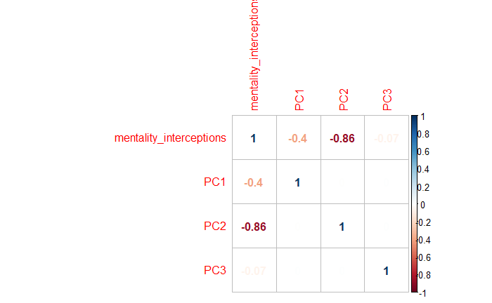

```r
reg_data <-
  as.data.frame(cbind(scale(short_db[c(idx_var_answer)]), acp$x[, 1:3]))
cor_reg_data <- cor(reg_data)
corrplot(cor_reg_data, method = "number")
```

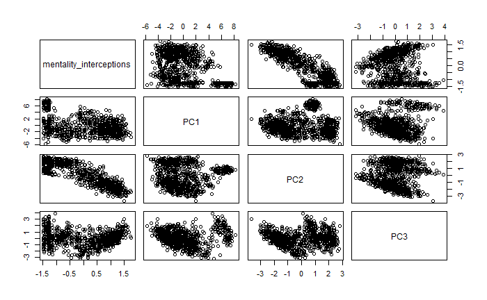

```r
pairs(reg_data)
```

### Analisis de las variables nuevas seleccionadas generadas por el ACP

```r
idx <- 3
acp_abs <- abs(acp$rotation[, idx])
rel_acp <- acp$rotation[acp_abs >= max(acp_abs) / 2, idx]
pos_acp <- data.frame(rel_acp[rel_acp >= 0])
neg_acp <- data.frame(rel_acp[rel_acp < 0])
pos_acp
```

|  | rel_acp.rel_acp....0. |
| --- | --- |
| overall | 0.6034566 |
| potential | 0.5457409 |

```r
neg_acp
```

|  | rel_acp.rel_acp...0. |
| --- | --- |
| movement_balance | -0.3869755 |

### Regresión lineal multiple

```r
model <- lm("mentality_interceptions ~ .", data = reg_data)
summary(model)
```

```
Call:
lm(formula = "mentality_interceptions ~ .", data = reg_data)

Residuals:
     Min       1Q   Median       3Q      Max
-1.19642 -0.15499  0.00418  0.16314  1.11200

Coefficients:
              Estimate Std. Error t value Pr(>|t|)
(Intercept) -3.072e-16  1.025e-02   0.000        1
PC1         -1.331e-01  3.399e-03 -39.149  < 2e-16 ***
PC2         -5.466e-01  6.486e-03 -84.271  < 2e-16 ***
PC3         -5.582e-02  8.720e-03  -6.401 2.59e-10 ***
---
Signif. codes:  0 ‘***’ 0.001 ‘**’ 0.01 ‘*’ 0.05 ‘.’ 0.1 ‘ ’ 1

Residual standard error: 0.2951 on 824 degrees of freedom
Multiple R-squared:  0.9133,    Adjusted R-squared:  0.9129
F-statistic:  2892 on 3 and 824 DF,  p-value: < 2.2e-16
```

### Analisis de los supuestos

```r
"Media de los Errores"
```

```
[1] "Media de los Errores"
```

```r
mean(model$residuals)
```

```
[1] 8.170144e-19
```

```r
"Suma de los Errores"
```

```
[1] "Suma de los Errores"
```

```r
sum(model$residuals)
```

```
[1] 6.921547e-16
```

```r
dwtest(model)
```

```
    Durbin-Watson test

data:  model
DW = 1.999, p-value = 0.4814
alternative hypothesis: true autocorrelation is greater than 0
```

```r
shapiro.test(model$residuals)
```

```
    Shapiro-Wilk normality test

data:  model$residuals
W = 0.97401, p-value = 5.602e-11
```

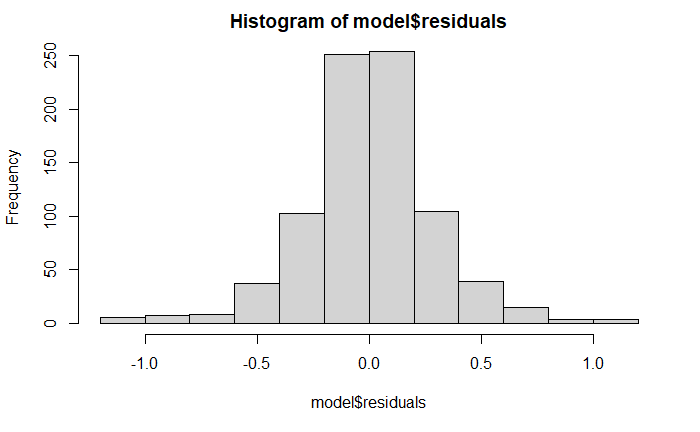

```r
hist(model$residuals)
```

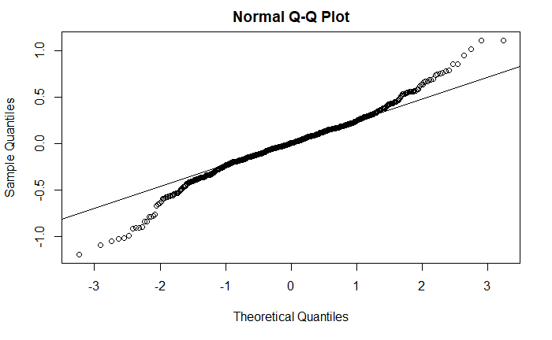

```r
qqnorm(model$residuals)
qqline(model$residuals)
```

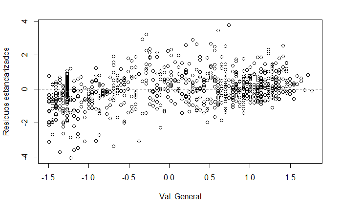

```r
plot(reg_data$mentality_interceptions,
     rstandard(model),
     ylab = "Residuos estandarizados",
     xlab = "Val. General")
abline(h = 0, lty = 2)
```

```r
bptest(model)
```

```
    studentized Breusch-Pagan test

data:  model
BP = 47.667, df = 3, p-value = 2.507e-10
```

## Anova

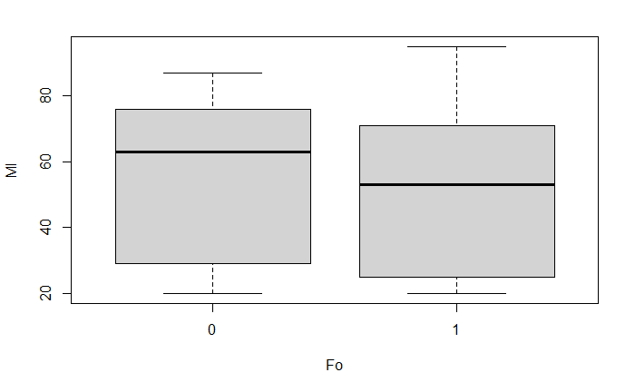

```r
MI = c(short_db$defending_sliding_tackle)
Fo = as.numeric(c(uefa_db$preferred_foot == 'Right'))
data_anova = data.frame(Fo, MI)
boxplot(MI ~ Fo, data=data_anova)
```

```r
anova_model = aov(MI ~ Fo, data = data_anova)
summary(anova_model)
```

```
             Df Sum Sq Mean Sq F value  Pr(>F)
Fo            1   4176    4176   8.443 0.00376 **
Residuals   826 408605     495
---
Signif. codes:  0 ‘***’ 0.001 ‘**’ 0.01 ‘*’ 0.05 ‘.’ 0.1 ‘ ’ 1
```

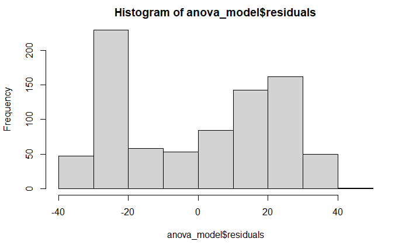

```r
hist(anova_model$residuals)
```

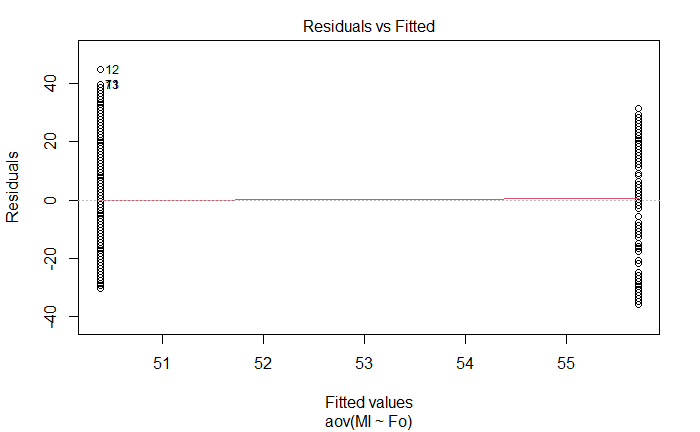

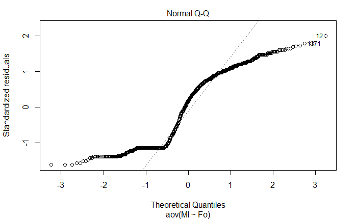

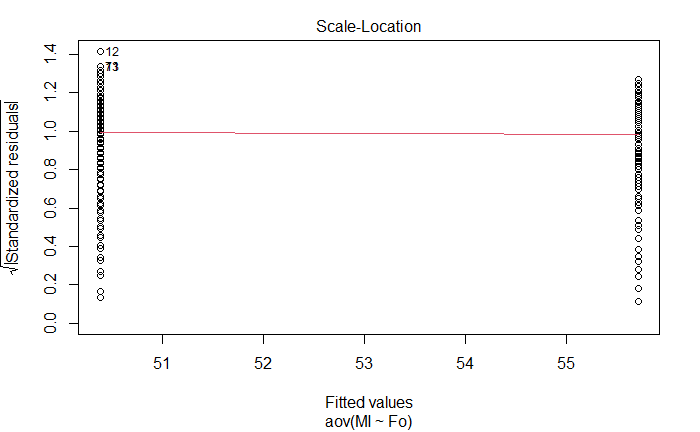

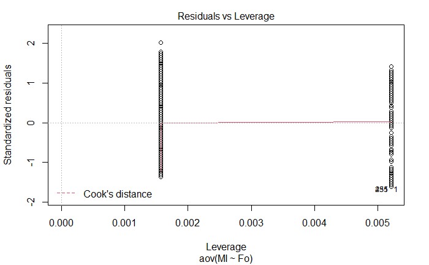

```r
plot(anova_model)
```

```r
shapiro.test(anova_model$residuals)
```

```
    Shapiro-Wilk normality test

data:  anova_model$residuals
W = 0.89162, p-value < 2.2e-16
```

```r
bartlett.test(anova_model$residuals, data_anova$Fo)
```

```
    Bartlett test of homogeneity of variances

data:  anova_model$residuals and data_anova$Fo
Bartlett's K-squared = 0.013901, df = 1, p-value = 0.9061
```

```r
dwtest(anova_model)
```

```
    Durbin-Watson test

data:  anova_model
DW = 1.8366, p-value = 0.009299
alternative hypothesis: true autocorrelation is greater than 0
```

## Clusters

En el siguiente análisis utilizando clústeres se tomó como referencia los resultados obtenidos del análisis de las componentes principales, en las que según el críterio del porcentaje el resultado era dos componentes principales y según el críterio de Kaiser el resultado era tres componentes principales.

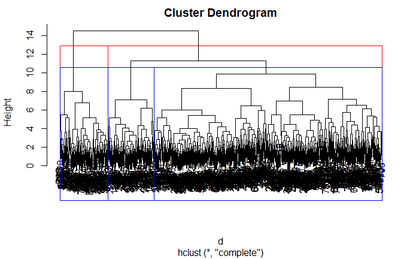

```r
clusters <- function(data, ks, colors, method = "euclidean") {
  d <- dist(data, method = method)
  fit <- hclust(d, method = "complete")

  # filename <-
    # paste("images/hier_cluster", "_", k, "_", method, ".png", sep = "")
  # png(filename = filename)
  plot(fit)
  i <- 1
  while (i <= length(ks)) {
    rect.hclust(fit, k = ks[i], border = colors[i])
    i <- i + 1
  }
  # dev.off()
}

data_clusters = as.data.frame(scale(short_db))

clusters(data_clusters, c(2, 3), c("red", "blue"))
```

Analizando el dendrograma se puede observar que tanto para dos como para tres clústeres existe uno de los clústeres que tiene la mayoría de los datos, por lo que se analizó aumentar la cantidad de clústeres a 4, 5, 6 y 7 para analizar el comportamiento con estas cantidades.

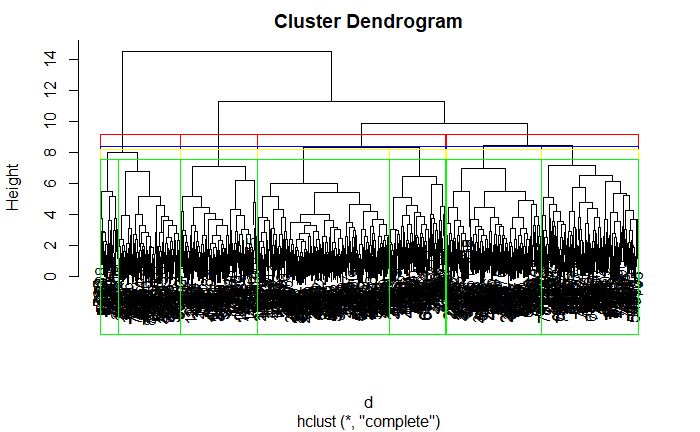

```r
clusters(data_clusters, c(4, 5, 6, 7), c("red", "blue", "yellow", "green"))
```

Del análisis anterior se eligió 6 clústeres como medidor principal debido a que con 4 y 5 clústeres permanecía una diferencia sustancial en cuanto a la cantidad de datos en cada clúster, y con 7 clústeres no se observó una mejora sobre a elección de 6 clústeres. Tomando en cuenta que se están segmentando en grupos a jugadores de futbol según sus características, 6 grupos no es una división exagerada, ya que los jugadores se pueden dividir por posiciones en el campo, estilo, portero, defensas centrales, laterales, mediocampistas defensivos, medio campistas ofencivos y delanteros. No quiere decir que el análisis con 6 clústeres determine estos grupos, solamente se quisó ilustrar que una clasificación en 6 grupos a los futbolistas no es una división extraña.

## K-Means

Se realizó un análisis utilizando el algoritmo de K-medias. Se utilizaron 6 particiones basándose en el resultado del análisis de los clústeres.

```
K-means clustering with 6 clusters of sizes 209, 96, 131, 83, 151, 158

Cluster means:
     overall  potential attacking_finishing attacking_short_passing skill_ball_control
1  0.5132358  0.3411253           0.3379355               0.7265980         0.61020175
2 -0.2429575 -0.5144791          -1.4553263              -2.1956346        -2.29124647
3 -0.6969268 -0.3539542           0.6626823              -0.1815608         0.17342625
4 -1.6754556 -1.3501545          -0.9238194              -0.5890226        -0.61240001
5  0.7845407  0.7853342           1.1542127               0.7077816         0.85331056
6  0.1769127  0.1135452          -0.7299853               0.1564573        -0.05260782
  skill_fk_accuracy skill_long_passing movement_agility movement_balance
1         0.6533200          0.8416485        0.4095844       0.40739286
2        -1.4371836         -1.9134466       -1.4816150      -1.41789902
3        -0.0549479         -0.5325294        0.3130685       0.24048743
4        -0.6811272         -0.5313792       -0.5725308      -0.08669947
```

[output cut: 47 more lines]

[figure not shown]

```r
k_means <- function(data, k) {
  km <- kmeans(data, k)

  print(km)

  # filename <- paste("images/kmeans_cluster", "_", k, ".png", sep = "")
  # png(filename = filename)
  plot(data, col = km$cluster)
  # dev.off()
}

k_means(data_clusters, 6)
```

## Árboles de Decisión

```
diag.pred          51 54 55 56 57 58 59 60 61 62 63 64 65 66 67 68 69 70 71 72 73 74 75 76
  60.183908045977   1  1  2  2  8  5  2  5  1  2  5  1  5  1  1  1  1  3  0  0  1  2  0  0
  68.0666666666667  0  0  0  0  0  0  0  0  0  0  1  0  1  1  1  2  1  2  0  3  2  1  1  0
  69.8275862068966  0  0  0  0  0  0  0  0  1  0  0  1  0  0  1  2  1  2  1  4  7  5  1  0
  71.5220125786164  0  0  0  1  1  0  0  3  0  3  1  1  1  2  2  2  3  2  4  5  4  1  5 13
  77.5268817204301  0  0  0  0  0  0  0  0  0  0  0  0  0  0  0  0  1  1  0  0  2  2  2  6
  79.1290322580645  0  0  0  0  0  0  0  0  0  1  0  0  0  1  0  0  0  0  0  2  0  3  0  1
  84.468085106383   0  0  0  0  0  0  0  0  0  0  0  0  0  0  0  0  1  1  0  0  1  0  0  0

diag.pred          77 78 79 80 81 82 83 84 85 86 87 89 90
  60.183908045977   0  0  0  0  0  0  0  0  0  0  0  0  0
  68.0666666666667  0  0  0  0  0  0  0  0  0  0  0  0  0
  69.8275862068966  0  0  0  0  0  0  0  0  0  0  0  0  0
  71.5220125786164  3  8  2  2  3  2  0  0  0  0  0  0  0
  77.5268817204301  3  3  7  6  3  3  0  0  0  0  0  0  0
  79.1290322580645  3  1  7  4  5  7  7  2  2  0  0  0  0
  84.468085106383   1  1  0  2  2  1  3  2  2  2  4  1  1
[1] 0.9927536
```

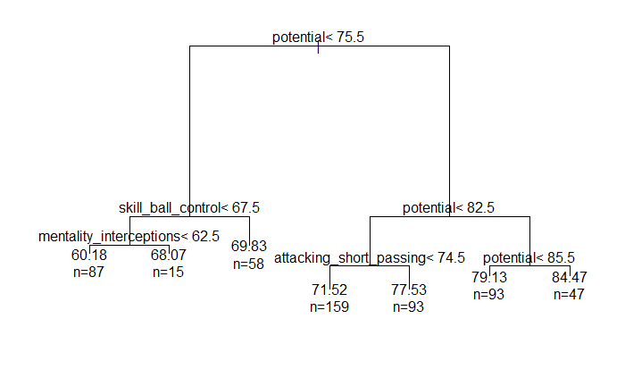

```r
d_tree <- function(data, var, depth) {
  n <- length(data[, 1])

  model <- paste(var, "~ .")

  sub <- sample(1:n, 2 * n / 3)

  diag.tree <-
    rpart( model, data = data[sub, ], cp = 0.01, maxdepth = depth)

  # summary(diag.tree)

  # filename <-
  #   paste("images/d_tree_cluster", "_", var, "_", depth, ".png", sep = "")
  # png(filename = filename)
  plot(diag.tree)
  text(diag.tree,
       use.n = TRUE,
       all = FALSE,
       pretty = 1,
       xpd = TRUE)
  # dev.off()

  # plotcp(diag.tree)
  # printcp(diag.tree)

  diag.pred <-
    predict(diag.tree, newdata = data[-sub, ], type = "vector")

  tb <- table(diag.pred, data[-sub, ][[var]])

  error.rpart <- 1 - (sum(diag(tb)) / sum(tb))
  print(tb)
  print(error.rpart)
}

d_tree(short_db, "overall", 3)
```

En un inicio, debido a que el modelo de regresión lineal no fue útil, ya que se incumplieron sus supuestos, se decidió realzar un análisis utilizando árboles de decisión, en primer árbol de decisión se realizó utilizando las 17 variables seleccionadas y como variable respuesta a overall, el resultado se puede observar a continuación, pero el error es del 99% por lo que se intento con un segundo árbol de decisión utilizando como variable respuesta mentality_interceptions y como variables independientes a las componentes principales, nuevamente el error fue alto, cercano al 98%.

[output not shown]

[output cut: 121 more lines]

```
  -1.12954612531034                 0                0                0                0
  -0.787629196369539                0                0                0                0
  0.185418805961837                 0                0                0                0
  0.328396526505983                 0                0                0                0
  0.851885224323642                 1                1                0                1
  1.17867144333569                  5                1                2                0

diag.pred            1.54196823290838 1.63123270168054 1.7204971704527
  -1.12954612531034                 0                0               0
  -0.787629196369539                0                0               0
  0.185418805961837                 0                0               0
  0.328396526505983                 0                0               0
  0.851885224323642                 0                0               0
  1.17867144333569                  2                1               1
[1] 0.9782609
```

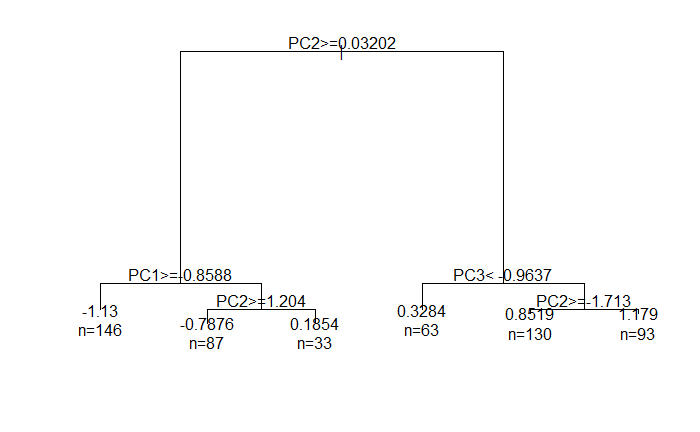

```r
d_tree(reg_data, "mentality_interceptions", 3)
```